# AI & Machine Learning - Unit 2

# The curse of dimensionality

- The number of training samples must **grow exponentially with dimensionality** if we want to maintain the same "density"
- This also means [informally] that if you increase the input dimension, the number of your training samples should grow exponentially to have the same performance and **avoid "overfitting"**.
- More on overfitting later but let's say for now that **overfitting = ML method not working well**

[figure not shown]

Figure Credit [DeepAI](https://deepai.org/machine-learning-glossary-and-terms/curse-of-dimensionality)

# Ambient space

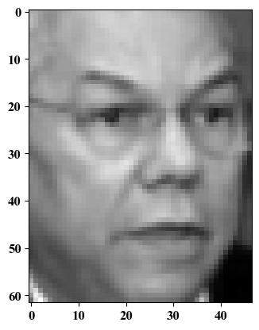

```python
_=plt.imshow(faces.data[0*N_img].reshape(62, 47), cmap='gray')
```

# Embedded space

$$\underbrace{\mathbf{I}}_{\text{what you see}} = \mathcal{G}(\text{id}, \text{pose}, \text{age}, \text{etnicity}, \text{illumination})$$

Faces may be "living" in a lower embedded space defined by:

1. Identity
2. Pose
3. Age
4. Ethnicity etc.

# Stranger things happen in higher dimensions

- As **D** increases, the volume of the hypersphere goes to zero while the hyper-cube remains constant.
- Training samples may be located at the corners of the hypercube.

[figure not shown]

Credit [Vincent Spruyt](https://www.visiondummy.com/2014/04/curse-dimensionality-affect-classification/)

[figure not shown]

### Distances in high-dimensional space

Distances in high dimensions follow a pattern:

[figure not shown]

[Figure Credit from this paper](https://openaccess.thecvf.com/content_ICCV_2017/papers/Zhang_Learning_Spread-Out_Local_ICCV_2017_paper.pdf)

[See this chapter for more explanations](http://ciml.info/dl/v0_99/ciml-v0_99-ch03.pdf)

## Dimensionality in ML: some reference numbers

- `D ≈ 20` is considered “low dimensional,”
- `D ≈ 1,000` is “medium dimensional”
- `D ≈ 100,000` is “high dimensional”.

# Eigenfaces (i.e. PCA applied to 2D images)

```python
from sklearn.decomposition import PCA
```

```python
pca = PCA(n_components=150) # retain 150 components
print(faces.data.shape) #NxD N=1348 samples in ~3K-D space
pca.fit(faces.data)
```

```
(1348, 2914)
```

```
PCA(n_components=150)
```

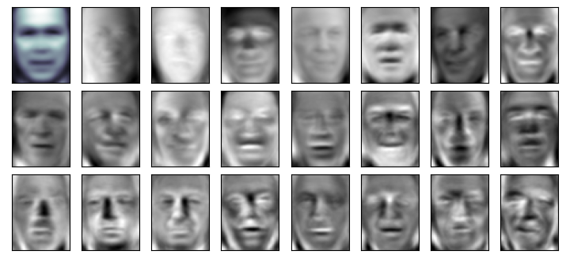

```python
fig, axes = plt.subplots(3, 8, figsize=(9, 4),
                         subplot_kw={'xticks':[], 'yticks':[]},
                         gridspec_kw=dict(hspace=0.1, wspace=0.1))
for i, ax in enumerate(axes.flat):
    if i == 0:
        ax.imshow(pca.mean_.reshape(62, 47), cmap='bone') #  plot mean
    else:
        ax.imshow(pca.components_[i].reshape(62, 47), cmap='gray') # plots components
```

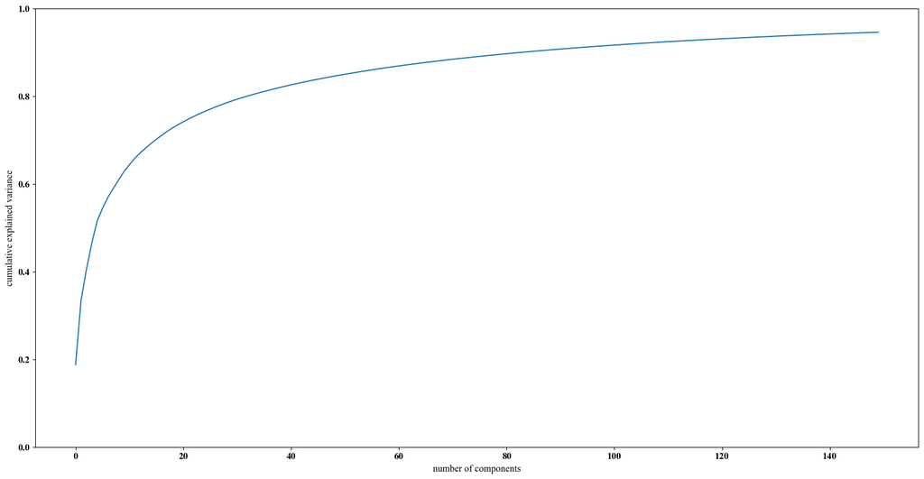

```python
plt.figure(figsize=(20,10))
plt.plot(np.cumsum(pca.explained_variance_ratio_))
plt.xlabel('number of components')
plt.ylabel('cumulative explained variance');
_ = plt.ylim([0,1])
```